# **NOTE:** Use File > Save a copy in Drive to make a copy before doing anything else

# Project 6: Data Exploration and Visualization

### Overview

In this project, you will apply data exploration and visualization techniques to a real-world dataset of your choice. You'll practice using pandas for data analysis and create meaningful visualizations to gain insights from your data. This project builds on your Python programming skills while introducing you to the exciting world of data science.

In [Lab6](https://colab.research.google.com/drive/1WxHaCZlN8d0kVgTCBmbMWmF29TM4pDJs?usp=sharing), you explore the titanic dataset and you should use it as a sample and pick a dataset of your interest to do a similar data exploration and visualization.

### Project Objectives

- Find and select a dataset from a real-world data source
- Formulate a clear inquiry question based on your chosen dataset
- Perform exploratory data analysis using pandas functions
- Create at least two meaningful data visualizations
- Analyze your findings and answer your inquiry question
- Reflect on the insights gained through data exploration

### Data Sources

You can choose from various online data sources such as:

- [Kaggle](https://www.kaggle.com/datasets) - Wide variety of datasets
- [data.gov](https://www.data.gov/) - U.S. government data
- [Our World in Data](https://ourworldindata.org/) - Global development data
- [GitHub](https://github.com/datasets) - Curated datasets
- [Google Dataset Search](https://datasetsearch.research.google.com/) - Search for datasets
- Or any other reliable data source you find interesting

## Part 1: Dataset Selection and Initial Exploration

#### TODO Tasks:

1. Select Your Dataset: Choose a dataset that interests you. Make sure it has at least 100 rows and multiple columns with different data types (e.g., numerical, categorical, dates).

Please create either text or code cells in between the TODO tasks to do the work.

2. Import Libraries: Import the necessary libraries (pandas, matplotlib, seaborn) at the beginning of your notebook by creating code cells below this text cell.

```python
!pip install pandas==2.2.2
!pip install seaborn==0.13.2
```

```python
from matplotlib import pyplot as plt
import seaborn as sns
```

3. Load Your Data: Load your chosen dataset using pandas and save it to a pandas dataframe. Please create a code cell below this text cell to do it.

```python
# @title Load the data

import pandas as pd

URL = "https://raw.githubusercontent.com/datasets/rio2016/refs/heads/main/athletes.csv"
df = pd.read_csv(URL)
```

4. Data Summary: Use the following functions to do inital exploration your dataset:
- info() - Display information about the dataset structure
- describe() - Show statistical summary of numerical columns
- head() - Display the first 5 rows (df.head())
- shape - Show the dimensions of the dataset (e.g. df.shape)
- columns - Get the column names (e.g. df.columns)

You may use 5 code cells below this text cell to accomplish it.

```python
df.info()
```

```
<class 'pandas.core.frame.DataFrame'>
RangeIndex: 11538 entries, 0 to 11537
Data columns (total 12 columns):
 #   Column         Non-Null Count  Dtype
---  ------         --------------  -----
 0   id             11538 non-null  int64
 1   name           11538 non-null  object
 2   nationality    11538 non-null  object
 3   sex            11538 non-null  object
 4   date_of_birth  11538 non-null  object
 5   height         11208 non-null  float64
 6   weight         10879 non-null  float64
 7   sport          11538 non-null  object
 8   gold           11538 non-null  int64
 9   silver         11538 non-null  int64
 10  bronze         11538 non-null  int64
 11  info           131 non-null    object
dtypes: float64(2), int64(4), object(6)
memory usage: 1.1+ MB
```

```python
df.describe()
```

|  | id | height | weight | gold | silver | bronze |
| --- | --- | --- | --- | --- | --- | --- |
| count | 1.153800e+04 | 11208.000000 | 10879.000000 | 11538.000000 | 11538.000000 | 11538.000000 |
| mean | 4.999885e+08 | 1.766260 | 72.072525 | 0.057722 | 0.056769 | 0.061016 |
| std | 2.908648e+08 | 0.112656 | 16.174778 | 0.255910 | 0.239147 | 0.243320 |
| min | 1.834700e+04 | 1.210000 | 31.000000 | 0.000000 | 0.000000 | 0.000000 |
| 25% | 2.450997e+08 | 1.690000 | 60.000000 | 0.000000 | 0.000000 | 0.000000 |
| 50% | 5.002011e+08 | 1.760000 | 70.000000 | 0.000000 | 0.000000 | 0.000000 |
| 75% | 7.539874e+08 | 1.840000 | 81.000000 | 0.000000 | 0.000000 | 0.000000 |
| max | 9.999878e+08 | 2.180000 | 170.000000 | 5.000000 | 2.000000 | 2.000000 |

```python
df.head()
```

|  | id | name | nationality | sex | date_of_birth | height | weight | sport | gold | silver | bronze | info |
| --- | --- | --- | --- | --- | --- | --- | --- | --- | --- | --- | --- | --- |
| 0 | 736041664 | A Jesus Garcia | ESP | male | 1969-10-17 | 1.72 | 64.0 | athletics | 0 | 0 | 0 | NaN |
| 1 | 532037425 | A Lam Shin | KOR | female | 1986-09-23 | 1.68 | 56.0 | fencing | 0 | 0 | 0 | NaN |
| 2 | 435962603 | Aaron Brown | CAN | male | 1992-05-27 | 1.98 | 79.0 | athletics | 0 | 0 | 1 | NaN |
| 3 | 521041435 | Aaron Cook | MDA | male | 1991-01-02 | 1.83 | 80.0 | taekwondo | 0 | 0 | 0 | NaN |
| 4 | 33922579 | Aaron Gate | NZL | male | 1990-11-26 | 1.81 | 71.0 | cycling | 0 | 0 | 0 | NaN |

```python
df.shape
```

```
(11538, 12)
```

```python
df.columns
```

```
Index(['id', 'name', 'nationality', 'sex', 'date_of_birth', 'height', 'weight',
       'sport', 'gold', 'silver', 'bronze', 'info'],
      dtype='object')
```

5. Inquiry Question: Write a clear, specific question that you want to answer using your dataset by creating a text cell below and **write the question in bold please.**

For example:

- "How has the average temperature changed in major cities over the past decade?"
- "What factors are most strongly correlated with housing prices?"
- "Is there a relationship between education level and income?"

**What is the distribution of medals (gold, silver, bronze) across different sports in the Rio 2016 Olympics?**

## Part 2: Data Visualization and Analysis

#### TODO Tasks:

1. Data Cleaning (if necessary): Check for and handle any missing values, duplicates, or data quality issues.

**NOTE: This could be a daunting task even for seasoned data scientists. My suggestion is to use a dataset that is already clean if you can for the purpose of completing this assignment in a week.**

Examples:

- Checking for missing values: df.isnull().sum()
- Dropping rows with any missing values: df.dropna(inplace=True)
- Dropping columns with all missing values: df.dropna(axis=1, how='all', inplace=True)
- Removing duplicate row: df.drop_duplicates(inplace=True)

```python
df.dropna(inplace=True)
df.drop_duplicates(inplace=True)
print("\nDataFrame shape after cleaning:", df.shape)
```

```
DataFrame shape after cleaning: (124, 12)
```

2. Create Visualizations: Create at least 2 different types of visualizations that help answer your research question. Choose from:
- Bar charts
- Line plots
- Scatter plots
- Histograms
- Box plots
- Heatmaps
- Any other appropriate visualization
3. Customize Your Plots: Make sure your visualizations are clear and informative by:
- Adding appropriate titles
- Labeling axes
- Using colors effectively
- Adding legends when necessary

Please create code cells below this to create your visualizations.

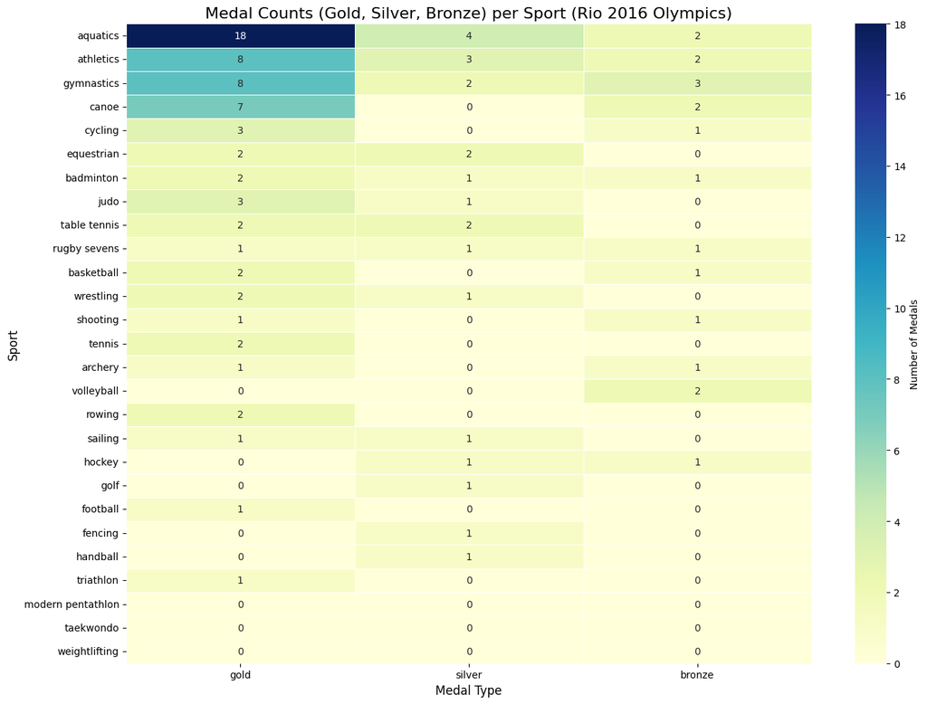

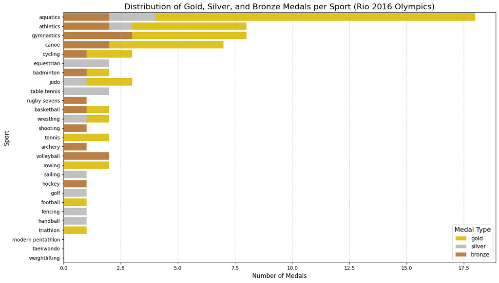

```python
# 1. Aggregate medal data by sport
medals_by_sport = df.groupby('sport')[['gold', 'silver', 'bronze']].sum().reset_index()
medals_by_sport['total_medals'] = medals_by_sport['gold'] + medals_by_sport['silver'] + medals_by_sport['bronze']

# Sort by total medals for better visualization
medals_by_sport_sorted = medals_by_sport.sort_values(by='total_medals', ascending=False)

# Visualization 1: Heatmap for medal counts per sport
plt.figure(figsize=(14, 10))
sns.heatmap(medals_by_sport_sorted.set_index('sport')[['gold', 'silver', 'bronze']],
            annot=True, fmt='d', cmap='YlGnBu', linewidths=.5, cbar_kws={'label': 'Number of Medals'})
plt.title('Medal Counts (Gold, Silver, Bronze) per Sport (Rio 2016 Olympics)', fontsize=16)
plt.xlabel('Medal Type', fontsize=12)
plt.ylabel('Sport', fontsize=12)
plt.tight_layout()
plt.show()

# Visualization 2: Stacked bar chart for medal distribution per sport (as before)
# Melt the dataframe to prepare for stacked bar plot
medals_melted = medals_by_sport_sorted.melt(id_vars=['sport'], value_vars=['gold', 'silver', 'bronze'],
                                            var_name='medal_type', value_name='count')

plt.figure(figsize=(14, 8))
sns.barplot(x='count', y='sport', hue='medal_type', data=medals_melted, dodge=False,
            palette={'gold': 'gold', 'silver': 'silver', 'bronze': '#CD7F32'})
plt.title('Distribution of Gold, Silver, and Bronze Medals per Sport (Rio 2016 Olympics)', fontsize=16)
plt.xlabel('Number of Medals', fontsize=12)
plt.ylabel('Sport', fontsize=12)
plt.legend(title='Medal Type', title_fontsize='13', fontsize='11')
plt.grid(axis='x', linestyle='--', alpha=0.7)
plt.tight_layout()
plt.show()
```

# 4. Analysis: Write 1-2 paragraphs discussing:

- Whether your research question can be answered with the available data
- What insights you discovered through your visualizations
- Any unexpected or interesting findings
- Limitations of your analysis
- Suggestions for further investigation

Please create a text cell below this cell to write your analysis.

My inquiry question was: What is the distribution of medals (gold, silver, bronze) across different sports in the Rio 2016 Olympics? Looking at both of my visualizations, I can clearly see the distribution of the medals. I noticed that both visualizations show that aquatics have the most overall medals in total and get the most gold medals. I also noticed that some sports only have one type of medal and not all three. One thing that surprised me was that some sports have no medals. One limitation of my analysis is that the dataset only focuses on individual athletes, so the data might not fully represent the comprehensive medal counts for an entire sport. One suggestion for further investigation would be to explore the full data set before cleaning it. I say this because after cleaning the dataset, I was left with only 124 rows, which is a significant drop from before. Looking at the full dataset may provide me with a more accurate and comprehensive understanding of the medal distribution.

## NOTE: If you use a local dataset, you MUST submit the dataset along with your notebook to get credit.

- Download your notebook as CS110_Project6.ipynb
- Ensure all TODO tasks are completed
- Make sure your code runs without errors
- Include clear comments explaining your work
- Submit the notebook file

## Grading Criteria (5 points)

- Dataset Selection: Appropriate choice of dataset with sufficient complexity (0.5 point)
- Inquiry Question: Clear, specific, and answerable with the chosen data (1 point)
- Data Exploration: Proper use of pandas functions for initial analysis (0.5 point)
- Visualizations: At least 2 clear, well-formatted, and relevant plots (1 point)
- Analysis: Thoughtful interpretation of findings and answer to research question (1 point)
- Code Quality: Clean, commented, and well-organized code (1 point)

Remember: The goal is not just to create visualizations, but to use them to gain meaningful insights about your data. Think like a data scientist and let your curiosity guide your exploration!